# Extra Credit Problem Set 3

[Population Ecology - EFB 370](https://eligurarie.github.io/EFB370)

#### Due date: Thursday, March 9, 2023, 11:59 pm.

#### Total Points: 0 (with 10 extra credit points)

> *Instructions:* *Submit this homework as a document. It can be entirely typed on a computer and uploaded on Blackboard, or completed as a combination of handwritten and printed (computer generated plots must be printed). Answer questions in complete sentences and explain how you obtained your answers. Only provide answers and include plots, do* **NOT** *send in code! Collaboration and discussion - openly and on the discussion forum - is highly encouraged, but do not provide and publicize actual answers.*

In this assignment, you will fit the logistic growth curve to (actual) data of the population of [England and Wales](https://en.wikipedia.org/wiki/England_and_Wales) from 1700-2000, using the tools we practiced in the [Week 7 Lab](https://eligurarie.github.io/EFB370/labs/lab7/Lab7.html).

You will need to download this dataset: englandwales_pop.csv, which has three columns: `year`, `year1700`, and `count`.  
The `count` is in terms of millions of people, the `year` is the year. The second time column, `year1700`, is *years since 1700*.

Here’s a plot of the data:

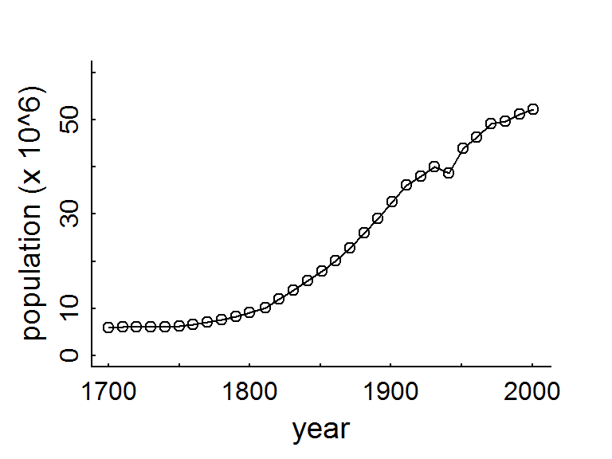

> **Hint 1:** Trust me when I say this whole exercise is A LOT easier if you use `year1700` rather than `year` for your analysis.

#### 1. (**1 pts**)

Load and plot the dataset, and comment on its shape, i.e. is it linear, exponential, sigmoidal?

> **Hint 2:** If you set the y-limits of the plot with the argument `ylim = c(0,60)` in the plot command here and throughout, you will getter a slightly better idea of what’s going on.

#### 2. (**2 pts**)

Fit a logistic curve to the data “by hand”, i.e. using the logistic function we used in Part I of the lab. Report your best guess for $N_0$, $r_0$ and $K$. Plot the fitted curve on the data.

#### 3. (**3 pts**)

Fit a logistic curve to the data using non-linear least squares. Report the *point estimates* and *95% Confidence Intervals* of the three parameters. Plot the fitted curve on the data.

#### 4. (**2 pts**)

Look up the current population of England and Wales. Compare that number with the *prediction* of your model in 2023. Is the population of England and Wales within the 95% confidence interval of carrying capacity according to your model? Remember, the solution to the logistic equation is given by:
$$\large N(t)
= {K \over {1 + \left({K - N_0\over N_0}\, e^{-r_0
t}\right)}}$$

#### 5. (**2 pt**)

Comment on how the logistic model fits these data. Are there any systematic biases? Can you explain them?

[figure not shown]

**England and Wales - chipping away at exponential growth.**